# Bayesian Improved Surname Geocoding and Addressing Racial Inequalities in Police Violence

2024-02-25

## Outline for tutorial

- Installing packages
- Cleaning processes
- Running BISG
- Validation
- Applications

## Checking and installing relevant packages

- Key BISG packages
  - WRU (Imai & Khanna, 2016) v. 0.1-12
  - zipWRUext2 (Clark, Curiel, and Steelman, 2021)
    - install from github
- Preamble “install pkgs” will ensure proper version of packages installed

## Install chunk

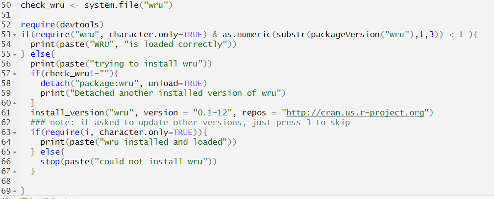

Version control code

## Loading in MPV data

```r
### read in the data
police <- read.csv("data/mpv_df.csv")
## change name for weapon field
colnames(police)[colnames(police)=="Alleged.Weapon..Source..WaPo.and.Review.of.Cases.Not.Included.in.WaPo.Database."] <-
  "alleged_weapon"
## change weapon field to lower case
police$alleged_weapon <- str_to_lower(police$alleged_weapon)
```

## Checking the data – or lack thereof

```r
knitr::kable(head(police[,1:5], 10))
```

| Victim.s.Full.name | First.name | Middle.name.initial | Last.name | Victim.s.age |
| --- | --- | --- | --- | --- |
| Name withheld by police | NA |  |  | 27 |
| Name withheld by police | NA |  |  | Unknown |
| Name withheld by police | NA |  |  | Unknown |
| Ronald W Flowers II | NA | W | Flowers II | Unknown |
| Name withheld by police | NA |  |  | Unknown |
| Name withheld by police | NA |  |  | 31 |
| Name withheld by police | NA |  |  | Unknown |
| Name withheld by police | NA |  |  | Unknown |
| Name withheld by police | NA |  |  | Unknown |
| Name withheld by police | NA |  |  | Unknown |

## Checking for withheld names

```r
### we will want a cleaner version to split of full_name
police$full_name <- police$Victim.s.Full.name

### note: some names are withheld by police
print(length(which(police$full_name=="Name withheld by police")))
```

[1] 226

```r
### note: 226 names withheld

# we will now want to create a dummy variable for later,
#since these will be information where we rely primarily on the geographic component.
police$name_withheld <- 0
police$name_withheld[police$full_name=="Name withheld by police"] <- 1
## assign generic name
police$full_name[police$full_name=="Name withheld by police"] <-
  "Noah A Smith"
```

## Cleaning names: Suffixes

```r
#### splitting names and pre-cleaning #####

### get rid of punctuation
police$full_name <- gsub("[[:punct:]]", " ", police$full_name )

suffix_vec <- c(" IV", " III", " II", " Jr", " Sr")

## loop through to get rid of suffixes
for (i in 1:length(suffix_vec)) {
  police$full_name <-
    str_replace_all(police$full_name,suffix_vec[i], "" )

}
```

## Splitting names part 1

```r
### now work on splitting names
police$first_name <- sapply(strsplit(police$full_name, " "), `[`, 1)
# for first name, we are grabbing the portion that is first before the space split.
# we can likewise see this by going with the "Noah A Smith" example
sapply(strsplit("Noah A Smith", " "), `[`, 1)
```

[1] “Noah”

```r
police$last_name <- sub(".* ", "", police$full_name)
# for last name, we are pulling the last portion of the full name
sub(".* ", "", "Noah A Smith") ## we will see what it does to name here; note, the name "Smith" is grabbed.
```

[1] “Smith”

```r
#looks like most do not have middle names ;
```

## Splitting names part 2

```r
print(summary(police$name_length))
```

Min. 1st Qu. Median Mean 3rd Qu. Max. 2.000 2.000 2.000 2.554 3.000 8.000

```r
### assign middle name of "A" based on if 2 length
police$middle_name <- sapply( strsplit(police$full_name, " "), tail, 1)
police$middle_name[police$name_length==2] <- "A"
head(police$last_name)
```

[1] “Smith” “Smith” “Smith” “Flowers” “Smith” “Smith”

## Prepping the geographic component

- Reading in sf police data object
  - Spatial intersected with Census Block Groups (CBGs)
  - NOTE: CBG shpfile too large to push to github
- Next steps: Reading in:

  -American Community Survey CBG & ZIP code data

  -Running BISG
  - Iterated on missing data/predictions

## ACS data of interest

```r
### read in the police sf data
police_sf <- readRDS("data/police_sf.rds")

## now read in the 5-year ACS data
cbfs_acs <- read.csv("data/acs2019bisgframe.csv") # CBG
zcta_acs <- readRDS("data/zcta_acs2016_2020.rds") # ZIP code
kable(head(cbfs_acs[,c(2,19:ncol(cbfs_acs))]))
```

| Geo_FIPS | r_whi | r_bla | r_his | r_asi | r_oth |
| --- | --- | --- | --- | --- | --- |
| 10010201001 | 0.0001897 | 0.0000465 | 0.0000336 | 0.0000000 | 0.0006235 |
| 10010201002 | 0.0003296 | 0.0000712 | 0.0000911 | 0.0000298 | 0.0010611 |
| 10010202001 | 0.0000836 | 0.0003926 | 0.0001438 | 0.0000000 | 0.0003391 |
| 10010202002 | 0.0001512 | 0.0004723 | 0.0000000 | 0.0000000 | 0.0003391 |
| 10010203001 | 0.0005841 | 0.0004313 | 0.0011168 | 0.0005521 | 0.0008860 |
| 10010203002 | 0.0001311 | 0.0002323 | 0.0000000 | 0.0000000 | 0.0001531 |

## Running BISG, CBGs

```r
##### Running BISG via the predict_any cmd (zipWRUext & wru) #####
### now, we should be able to run predict_any
police_df <- predict_race_any(police_df, cbfs_acs, c("Geo_FIPS"))
```

```
## [1] "All r_eth fields present."
## [1] "A total of 0 observations saw a failed geographic merge."
```

```r
# arguments: df to be imputed on, the df with the demographic data necessary for the BISG process (r_whi,r_bla,r_his,r_asi,r_oth) ; the fields common in both dfs to do the merge

head(police_df$pred_whi)
```

```
## [1] 0.7839463 0.8564566 0.8520308 0.1798455 0.7015068 0.8631205
```

## Check for missing data

```r
##### Cleaning up the missing data #####
### check to ensure no data missing
sum(is.na(police_df$pred_whi)) ## 24 missing; will want to use ZIP code to predict next
```

```
## [1] 24
```

```r
### subset
police_df_miss <- subset(police_df, is.na(pred_whi)==T)
police_df <- subset(police_df, is.na(pred_whi)==F)

### drop the empty fields
police_df_miss <- subset(police_df_miss, select=-c(pred_whi,pred_bla,pred_his,pred_asi,pred_oth))

#### read in the other missing data
police_coord_missing <-readRDS("data/police_coord_missing.rds")
## above split off from the sf version
```

## Running BISG by ZIP code

```r
### read in the zip code data
colnames(police_df_miss)[colnames(police_df_miss)=="Zipcode"] <- "zcta5"
police_df_miss <- predict_race_any(police_df_miss,zcta_acs,c("zcta5") )
```

```
## [1] "All r_eth fields present."
## [1] "A total of 0 observations saw a failed geographic merge."
```

```r
### no failed merges; check data
sum(is.na(police_df_miss$pred_whi)) # 1 missing observation
```

```
## [1] 1
```

```r
### run zip code bisg
colnames(police_coord_missing)[colnames(police_coord_missing)=="Zipcode"] <- "zcta5"
colnames(police_coord_missing)[colnames(police_coord_missing)=="last_name"] <- "surname"
police_coord_missing <- predict_race_any(police_coord_missing,zcta_acs,c("zcta5") )
```

```
## [1] "All r_eth fields present."
## [1] "A total of 0 observations saw a failed geographic merge."
```

```r
### check missing race data
sum(is.na(police_coord_missing$pred_whi)) # 13
```

```
## [1] 13
```

## BISG with surname alone

```r
### run the wru command for surname alone
police_df_miss_surname <- predict_race(police_df_miss_surname,
                                       surname.only = T)
```

```
## [1] "Proceeding with surname-only predictions..."
```

```r
police_coord_missing_surname <- predict_race(police_coord_missing_surname, surname.only = T)
```

```
## [1] "Proceeding with surname-only predictions..."
```

```r
### bind the data
police_df_miss_surname <- rbind(police_df_miss_surname,police_coord_missing_surname )

head(police_df_miss_surname$pred.whi)
```

```
## [1] 0.6964000 0.6538654 0.7277000 0.7090709 0.7090709 0.7592000
```

## Validation

Goals

- Compare accuracy of aggregated estimates
- Calculate precision by race
  - \(\frac{TP}{TP+FP}\)
- Estimate geographic sources of error

## Aggregate estimate comparisons

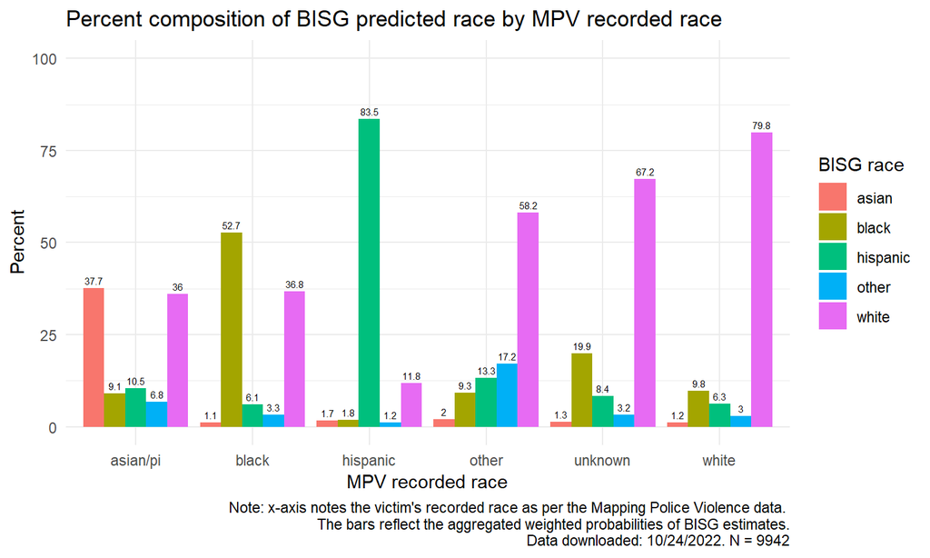

## Precision of BISG estimates

[figure not shown]

## Multilevel modeling

- DV: Whether MPV and BISG races match
  - 1 if true, 0 otherwise
- IVs at county level:
  - Segregation (Duncan-Duncan index)
  - Economic equality (Gini Index)
  - Metropolitan area type
  - Random intercepts by county
  - N = 8,959

## Multilevel modeling results

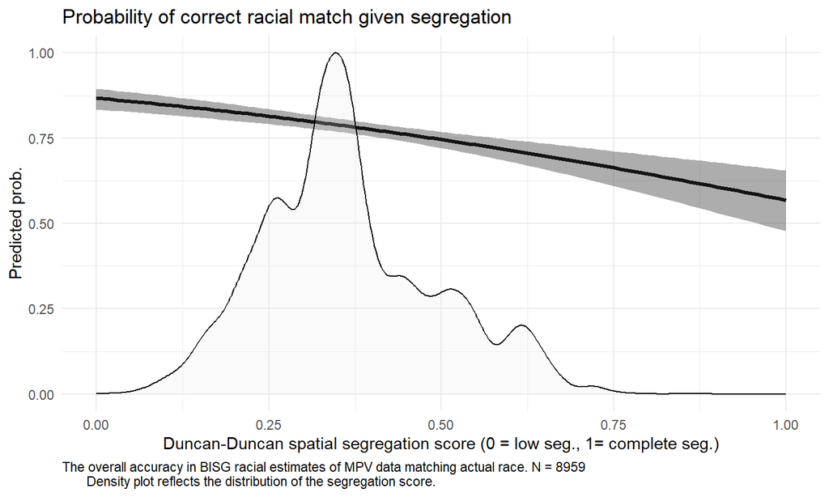

## Potential applications with BISG estimated data:

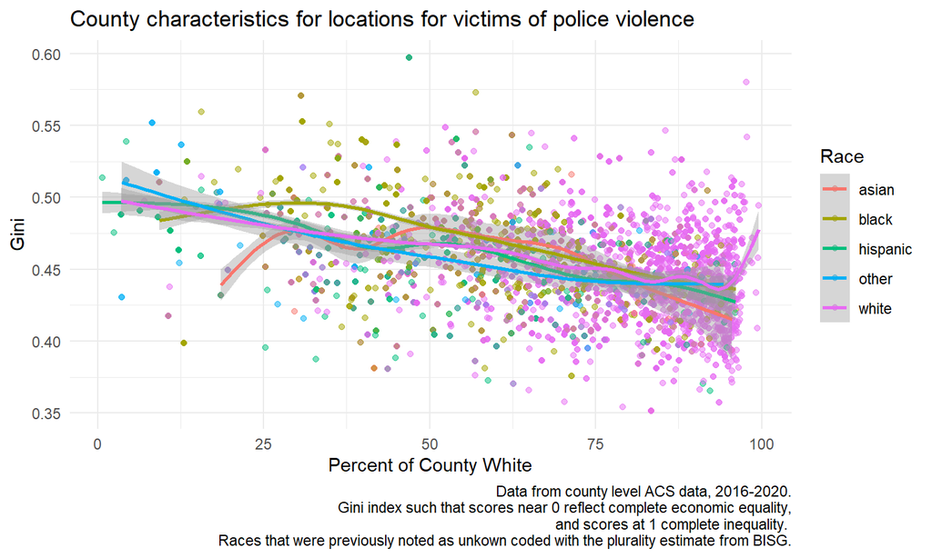

## Implications & Discussion

- BISG appears applicable to Mapping Police Violence data
- Most likely safe to impute for unknown race
- Should be possible to model noise
- Start using to uncover race of police officers?

## Future project: The police officer perpetrator database

| county | agency | mpv_id2 | officer_race | officer_name2 |
| --- | --- | --- | --- | --- |
| San Diego | San Diego Police Department | 17 | NA | Michael Martinez |
| San Diego | San Diego Police Department | 17 | NA | Michael Muniz |
| San Diego | San Diego Police Department | 17 | NA | Angel Vidrios |
| Clark | Las Vegas Metropolitan Police Department | 18 | NA | James Rothenburg |
| Clark | Las Vegas Metropolitan Police Department | 18 | NA | Kerry Kubla |
| Clark | Las Vegas Metropolitan Police Department | 18 | NA | Brice Clements |